# Training a Machine Learning algorithm on Human Excercise data

We begin by fitting the model

```r
model_lda <- train(classe ~ ., model = "lda", data = training)
model_lda$finalModel
```

```
Call:
 randomForest(x = x, y = y, mtry = param$mtry, model = "lda")
               Type of random forest: classification
                     Number of trees: 500
No. of variables tried at each split: 28

        OOB estimate of  error rate: 0.25%
Confusion matrix:
     A    B    C    D    E  class.error
A 3904    1    0    0    1 0.0005120328
B    7 2648    3    0    0 0.0037622272
C    0    6 2388    2    0 0.0033388982
D    0    0    8 2244    0 0.0035523979
E    0    1    0    6 2518 0.0027722772
```

```r
predict_lda <- predict(model_lda, validation)
head(predict_lda)
```

```
[1] A A A A A A
Levels: A B C D E
```

The accuracy for this model is:

```r
confusionMatrix(predict_lda, validation$classe)$overall
```

```
      Accuracy          Kappa  AccuracyLower  AccuracyUpper   AccuracyNull AccuracyPValue
     1.0000000      1.0000000      0.9991079      1.0000000      0.2830873      0.0000000
 McnemarPValue
           NaN
```

We begin by fitting the model

```r
model_nb <- train(classe ~ ., model = "nb", data = training)
model_nb$finalModel
```

```
Call:
 randomForest(x = x, y = y, mtry = param$mtry, model = "nb")
               Type of random forest: classification
                     Number of trees: 500
No. of variables tried at each split: 28

        OOB estimate of  error rate: 0.24%
Confusion matrix:
     A    B    C    D    E  class.error
A 3904    1    0    0    1 0.0005120328
B    8 2648    2    0    0 0.0037622272
C    0    6 2389    1    0 0.0029215359
D    0    0    9 2243    0 0.0039964476
E    0    1    0    4 2520 0.0019801980
```

```r
predict_nb <- predict(model_nb, validation)
head(predict_nb)
```

```
[1] A A A A A A
Levels: A B C D E
```

The accuracy for this model is:

```r
confusionMatrix(predict_nb, validation$classe)$overall
```

```
      Accuracy          Kappa  AccuracyLower  AccuracyUpper   AccuracyNull AccuracyPValue
     1.0000000      1.0000000      0.9991079      1.0000000      0.2830873      0.0000000
 McnemarPValue
           NaN
```

We begin by fitting the model

```r
model_gbm <- train(classe ~ ., model = "gbm", data = training)
model_gbm$finalModel
```

```
Call:
 randomForest(x = x, y = y, mtry = param$mtry, model = "gbm")
               Type of random forest: classification
                     Number of trees: 500
No. of variables tried at each split: 28

        OOB estimate of  error rate: 0.25%
Confusion matrix:
     A    B    C    D    E  class.error
A 3904    1    0    0    1 0.0005120328
B    8 2648    2    0    0 0.0037622272
C    0    6 2388    2    0 0.0033388982
D    0    0    8 2244    0 0.0035523979
E    0    1    0    6 2518 0.0027722772
```

```r
predict_gbm <- predict(model_gbm, validation)
head(predict_gbm)
```

```
[1] A A A A A A
Levels: A B C D E
```

The accuracy for this model is:

```r
confusionMatrix(predict_gbm, validation$classe)$overall
```

```
      Accuracy          Kappa  AccuracyLower  AccuracyUpper   AccuracyNull AccuracyPValue
     1.0000000      1.0000000      0.9991079      1.0000000      0.2830873      0.0000000
 McnemarPValue
           NaN
```

## Support Vector Machine

We begin by fitting the model

```r
model_svm <- svm(classe ~ ., data = training)
?svm
model_svm
```

```
Call:
svm(formula = classe ~ ., data = training)


Parameters:
   SVM-Type:  C-classification
 SVM-Kernel:  radial
       cost:  1

Number of Support Vectors:  6343
```

```r
predict_svm <- predict(model_svm, validation)
head(predict_svm)
```

```
 3 10 22 23 25 50
 A  A  A  A  A  A
Levels: A B C D E
```

The accuracy for this model is:

```r
confusionMatrix(predict_svm, validation$classe)$overall
```

```
      Accuracy          Kappa  AccuracyLower  AccuracyUpper   AccuracyNull AccuracyPValue
     0.9569320      0.9454969      0.9502908      0.9629171      0.2830873      0.0000000
 McnemarPValue
           NaN
```

## Combination

```r
df_all <- data.frame(predict_rf, predict_lda, predict_nb, predict_gbm, predict_svm, classe = validation$classe)
model_all <- train(classe ~ ., method = "rf", data = df_all)
model_all$finalModel
```

```
Call:
 randomForest(x = x, y = y, mtry = param$mtry)
               Type of random forest: classification
                     Number of trees: 500
No. of variables tried at each split: 2

        OOB estimate of  error rate: 0%
Confusion matrix:
     A   B   C   D   E class.error
A 1170   0   0   0   0           0
B    0 787   0   0   0           0
C    0   0 727   0   0           0
D    0   0   0 676   0           0
E    0   0   0   0 773           0
```

Now we try to predict once again using this new model:

```r
predict_all <- predict(model_all, validation)
head(predict_all)
```

```
[1] A A A A A A
Levels: A B C D E
```

With this accuracy:

```r
confusionMatrix(predict_all, validation$classe)$overall
```

```
      Accuracy          Kappa  AccuracyLower  AccuracyUpper   AccuracyNull AccuracyPValue
     1.0000000      1.0000000      0.9991079      1.0000000      0.2830873      0.0000000
 McnemarPValue
           NaN
```

## Predictions on Test data set

Since all models have a high accuracy, we will proceed to use only the Random Forest model to try to predict the results on the test set, which will be used on the quiz:

```r
predict_test <- predict(model_rf,testing)
predict_test
```

```
 [1] B A B A A E D B A A B C B A E E A B B B
Levels: A B C D E
```

# Appendix

Plot of the Random Forest model:

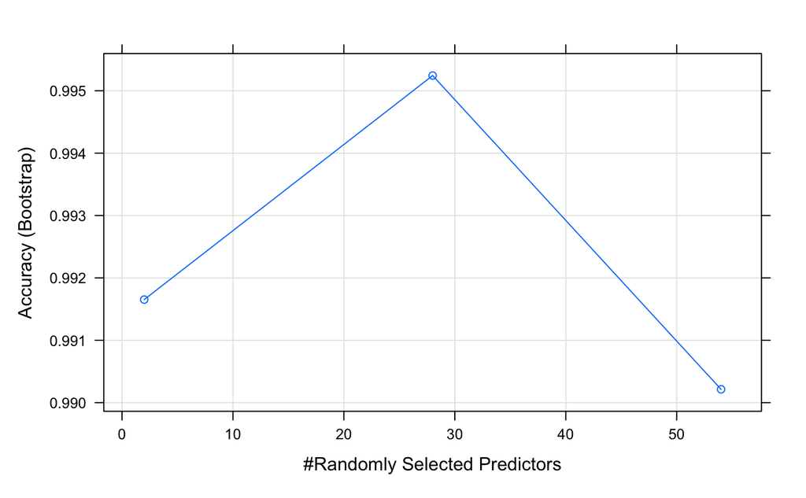

```r
plot(model_rf)
```

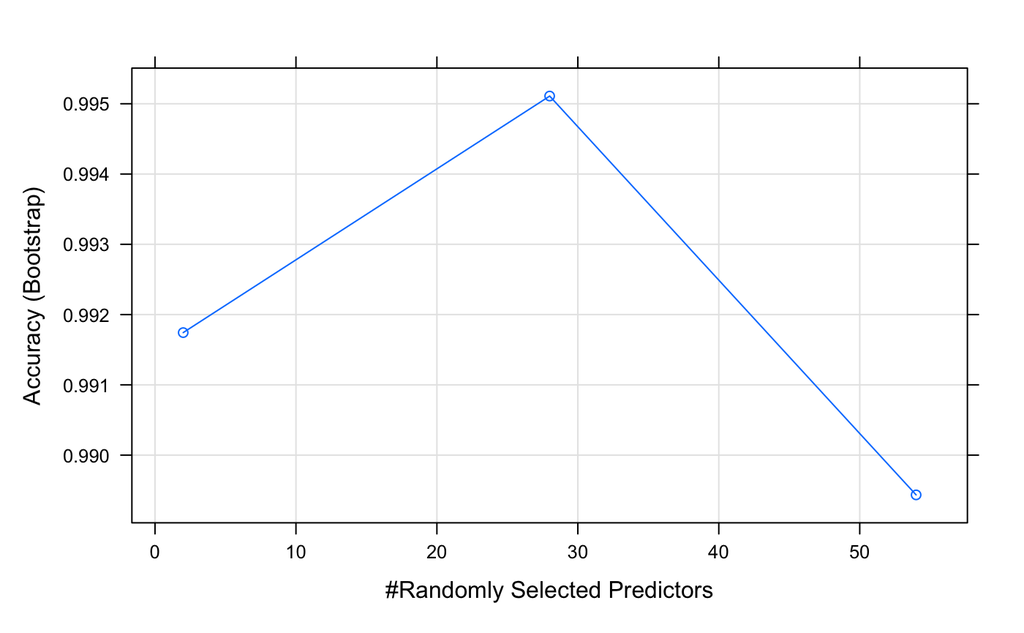

```r
plot(model_gbm)
```

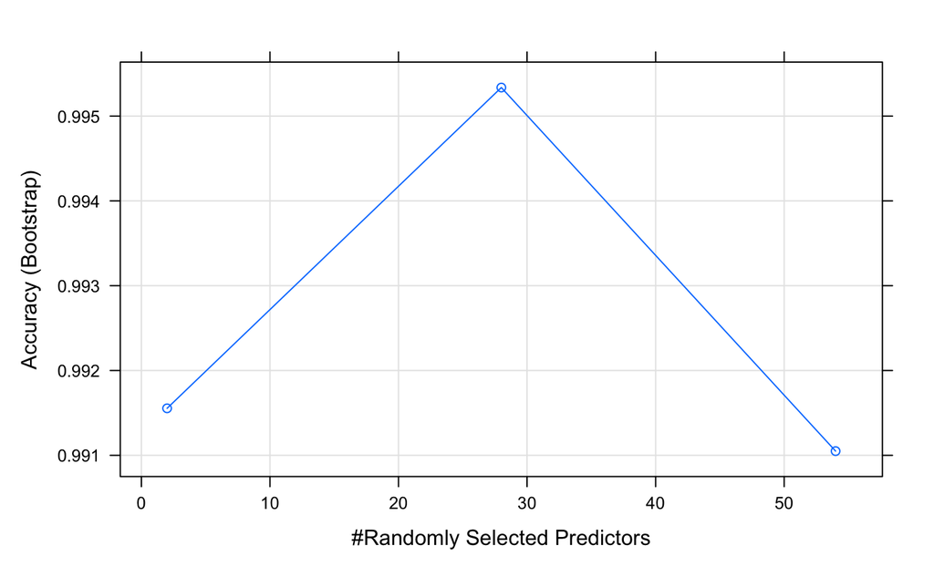

```r
plot(model_lda)
```

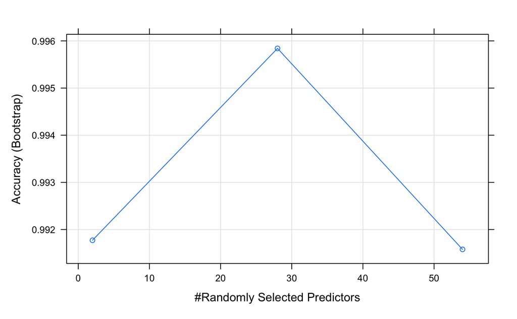

```r
plot(model_nb)
```